# STAT 385: Homework 01

Aniruddha Mukherjee - Spring 2020, UIUC

Due: Friday, February 7, 11:59 PM

## Instructions

- Maximum total number of points for this homework is 35.
- Download the R script template and write your R code in this file for submission.
- Rename the R script as `hw01-your-name.R`. For example, my R script file will be `hw01-ha-nguyen.R`.
- Make sure to include your name in the R script file.
- Submit the R script (`.R`) file to Compass by **11:59 PM on Friday, 02/07/2020**. You can submit as many times as needed up until the deadline. **The lastest version submitted will be graded**.

## Exercise 1: French Roulette

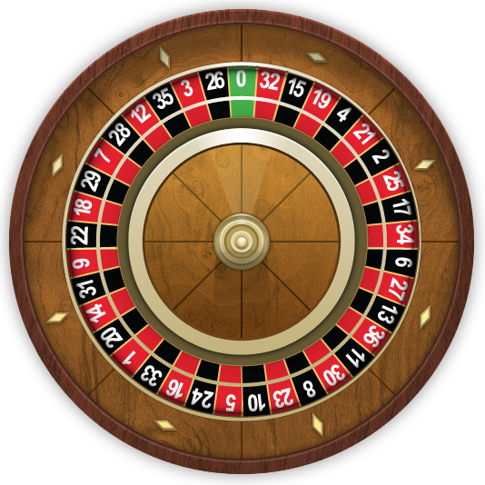

- A French roulette has:
  - **37 colored and numbered pockets** on the wheel.
  - 0 is green.
  - In number ranges from 1 to 10 and 19 to 28:
    - Odd numbers are red.
    - Even numbers are black.
  - In ranges from 11 to 18 and 29 to 36:
    - Odd numbers are black.
    - Even numbers are red.

```r
# import the data here
```

```r
# write your function here
```

- After finish writing your function, remove the `eval=FALSE` option in the chunk below to test your function.

```r
set.seed(385)
roulette(bet = 10)

set.seed(385)
roulette()

set.seed(385)
roulette(bet = 5)

set.seed(420)
roulette(bet = 4)

set.seed(400)
roulette(bet = 36)
```

## Exercise 2: Number of Mortgage Payments

Consider the following formula to calculate the number of mortgage payment terms:

$$n = \frac{ln \left( \frac{r}{\frac{m}{p} - r} + 1 \right)}{ln(1 + r)}$$

In the above formula, $m$ represents the monthly payment amount, $p$ is the principle, and $r$ is the (monthly) interest rate.

**TASK:** (5 points) Write an R function named `mortgage_num()` that calculates the number of mortgage payment terms using the above formula given $m$, $p$, and $r$.

```r
# write your function here
```

- Again, remove `eval=FALSE` in the chunk below to test your code:

```r
mortgage_num(m = 2000, p = 200000, r = 0.005)
mortgage_num(m = 1800, p = 200000, r = 0.005)
mortgage_num(m = 1500, p = 200000, r = 0.005)
```

## Exercise 3: Iris Flower Dataset

[figure not shown]

The [Iris flower dataset](https://www.kaggle.com/arshid/iris-flower-dataset) is one of the most well-known datasets in the data science world. For this exercise, we will take a quick look at this famous dataset. The `iris` dataset has already been loaded to R as a data frame called `iris`.

Type `iris` in your console window in RStudio to take a quick look at it.

**TASKS**: (10 points)

- **(a)** (1 point) Get the dimension (number of rows, number of columns) of the `iris` data frame.

```r
# dimensions of iris
```

- **(b)** (1 point) Print out the first 6 rows of `iris`.

```r
# first 6 rows of iris
```

- **(c)** (2 points) Compute the **average** of Sepal Length for Virginica Iris flowers only.

```r
# compute the average
```

- **(d)** (2 points) Similar to (c), we can also select only the Versicolor Iris flowers. Compute the **standard deviation** of the Petal Length for Versicolor Iris flowers only.

```r
# compute the standard deviation
```

- **(e)** (2 points) Compute the **median** of the Sepal Width for Setosa Iris flowers only.

```r
# compute the median
```

- **(f)** (2 points) In this dataset, how many rows are Setosa Iris flowers?

```r
# number of rows that are Setosa Iris flowers
```

## Exercise 4: Coronavirus

The coronavirus has been on the news over the past weeks. We will take a look at the data on this newly discovered virus. This dataset was obtained from [Kaggle](https://www.kaggle.com/brendaso/2019-coronavirus-dataset-01212020-01262020). The dataset contains the coronavirus cases recorded up to 01/26/2020. The `Confirmed` column represents the **cummulative** number of cases confirmed at the that day and time. For example, up to 1/26/2020 11:00 AM, there are 40 confirmed cases in Shanghai, China.

**TASKS**:

- **(a)** (5 points) Read the data in `coronavirus-2020-01-26.csv` file from the URL: https://nkha149.github.io/stat385-sp2020/files/data/coronavirus-2020-01-26.csv and stores the data as a data frame named `coronavirus`.
  - After loading the data, take a quick look at the dataset using the `str()` function.

[output not shown]

- To select only data for the United States, we can use the following command:

```r
coronavirus[coronavirus$Country == "United States", ]
```

- **(b)** (5 points) Follow the syntax in the code shown above, print out the lastest data on **confirmed** cases of the coronavirus.
  - Those are the rows that have `Data.last.updated` equals to `1/26/2020 11:00 AM`.
  - Only print out the following columns: `Province.State`, `Country`, `Date.last.updated`, and `Confirmed`.

```r
# filter data
```